# PDA_Project_US_Car_Accidents_Analysis

# Multiple Linear Regression

```r
multiplelm1 <- lm(Distance.mi.~., data=Accident_Training)
summary(multiplelm1)
```

```
##
## Call:
## lm(formula = Distance.mi. ~ ., data = Accident_Training)
##
## Residuals:
##     Min      1Q  Median      3Q     Max
##  -2.809  -0.712  -0.534   0.079 148.250
##
## Coefficients:
##                     Estimate Std. Error t value Pr(>|t|)
## (Intercept)        5.0257343  0.1202422  41.797   <2e-16 ***
## Temperature.F.     0.0341590  0.0023856  14.319   <2e-16 ***
## Wind_Chill.F.     -0.0337529  0.0021313 -15.837   <2e-16 ***
## Humidity...        0.0006315  0.0002329   2.711   0.0067 **
## Pressure.in.      -0.1364543  0.0041400 -32.960   <2e-16 ***
## Visibility.mi.    -0.0296511  0.0019817 -14.963   <2e-16 ***
## Wind_Speed.mph.   -0.0009403  0.0009545  -0.985   0.3245
## Precipitation.in. -0.0585772  0.0970306  -0.604   0.5460
## ---
## Signif. codes:  0 '***' 0.001 '**' 0.01 '*' 0.05 '.' 0.1 ' ' 1
##
## Residual standard error: 1.942 on 185884 degrees of freedom
## Multiple R-squared:  0.01395,    Adjusted R-squared:  0.01392
## F-statistic: 375.8 on 7 and 185884 DF,  p-value: < 2.2e-16
```

```r
ypred <-predict(object = multiplelm1, newdata = Accident_Testing)
summary(ypred)
```

```
##    Min. 1st Qu.  Median    Mean 3rd Qu.    Max.
## -1.4026  0.7102  0.7724  0.8563  0.9121  2.9183
```

```r
MAE(y_pred = ypred, y_true = Accident_Testing$Distance.mi.)
```

```
## [1] 0.9250965
```

```r
MSE(y_pred = ypred, y_true = Accident_Testing$Distance.mi.)
```

```
## [1] 3.524409
```

# Forward Stepwise regression

```r
intercept_only <- lm(Distance.mi. ~ 1, data= Accident_Training)
all <- lm(Distance.mi. ~., data=Accident_Training)
forward <- stepAIC (intercept_only, direction='forward',scope = formula(all))
```

```
## Start:  AIC=249273.3
## Distance.mi. ~ 1
##
##                     Df Sum of Sq    RSS    AIC
## + Pressure.in.       1    6018.4 704584 247694
## + Wind_Chill.F.      1    3244.0 707358 248425
## + Temperature.F.     1    2738.8 707863 248557
## + Visibility.mi.     1    2467.0 708135 248629
## + Humidity...        1     301.0 710301 249197
## + Wind_Speed.mph.    1     298.6 710304 249197
## + Precipitation.in.  1      42.3 710560 249264
## <none>                           710602 249273
##
## Step:  AIC=247694.2
## Distance.mi. ~ Pressure.in.
##
##                     Df Sum of Sq    RSS    AIC
## + Visibility.mi.     1   1996.64 702587 247169
## + Wind_Chill.F.      1   1745.60 702838 247235
## + Temperature.F.     1   1429.57 703154 247319
## + Humidity...        1    695.76 703888 247513
## + Wind_Speed.mph.    1    162.20 704422 247653
## + Precipitation.in.  1     46.93 704537 247684
## <none>                           704584 247694
##
## Step:  AIC=247168.7
## Distance.mi. ~ Pressure.in. + Visibility.mi.
##
##                     Df Sum of Sq    RSS    AIC
## + Wind_Chill.F.      1    945.58 701642 246920
## + Temperature.F.     1    721.93 701865 246980
## + Wind_Speed.mph.    1    165.32 702422 247127
## + Humidity...        1     81.03 702506 247149
## + Precipitation.in.  1      7.80 702579 247169
## <none>                           702587 247169
##
## Step:  AIC=246920.3
## Distance.mi. ~ Pressure.in. + Visibility.mi. + Wind_Chill.F.
##
##                     Df Sum of Sq    RSS    AIC
```

[output cut: 9 more lines]

```
##
##                     Df Sum of Sq    RSS    AIC
## + Humidity...        1   29.6259 700691 246672
## <none>                           700721 246678
## + Wind_Speed.mph.    1    6.7115 700714 246679
## + Precipitation.in.  1    0.7588 700720 246680
##
## Step:  AIC=246672.4
## Distance.mi. ~ Pressure.in. + Visibility.mi. + Wind_Chill.F. +
##     Temperature.F. + Humidity...
##
##                     Df Sum of Sq    RSS    AIC
## <none>                           700691 246672
## + Wind_Speed.mph.    1    3.9595 700688 246673
## + Precipitation.in.  1    1.6745 700690 246674
```

```r
summary(forward)
```

```
##
## Call:
## lm(formula = Distance.mi. ~ Pressure.in. + Visibility.mi. + Wind_Chill.F. +
##     Temperature.F. + Humidity..., data = Accident_Training)
##
## Residuals:
##     Min      1Q  Median      3Q     Max
##  -2.813  -0.712  -0.534   0.079 148.251
##
## Coefficients:
##                  Estimate Std. Error t value Pr(>|t|)
## (Intercept)     5.0241823  0.1202128  41.794  < 2e-16 ***
## Pressure.in.   -0.1364435  0.0041398 -32.959  < 2e-16 ***
## Visibility.mi. -0.0293990  0.0019486 -15.087  < 2e-16 ***
## Wind_Chill.F.  -0.0327255  0.0018546 -17.646  < 2e-16 ***
## Temperature.F.  0.0330010  0.0020787  15.876  < 2e-16 ***
## Humidity...     0.0006466  0.0002306   2.803  0.00506 **
## ---
## Signif. codes:  0 '***' 0.001 '**' 0.01 '*' 0.05 '.' 0.1 ' ' 1
##
## Residual standard error: 1.942 on 185886 degrees of freedom
## Multiple R-squared:  0.01395,    Adjusted R-squared:  0.01392
## F-statistic: 525.8 on 5 and 185886 DF,  p-value: < 2.2e-16
```

> > In summary, the final iteration model includes predictors Pressure.in., Visibility.mi., Wind_Chill.F., Temperature.F., and Humidity…, and it has the lowest AIC among the considered models. This model is chosen as it strikes a balance between model complexity and goodness of fit. It can be noted that the improvement made by adding humidity had a very small improvement.

```r
ypred_forward <-predict(object = forward, newdata = Accident_Testing)
MAE(y_pred = ypred_forward, y_true = Accident_Testing$Distance.mi.)
```

```
## [1] 0.9251014
```

```r
MSE(y_pred = ypred_forward, y_true = Accident_Testing$Distance.mi.)
```

```
## [1] 3.524496
```

# Backward Stepwise Regression

```r
backward <- stepAIC (all, direction='backward')
```

```
## Start:  AIC=246675
## Distance.mi. ~ Temperature.F. + Wind_Chill.F. + Humidity... +
##     Pressure.in. + Visibility.mi. + Wind_Speed.mph. + Precipitation.in.
##
##                     Df Sum of Sq    RSS    AIC
## - Precipitation.in.  1       1.4 700688 246673
## - Wind_Speed.mph.    1       3.7 700690 246674
## <none>                           700686 246675
## - Humidity...        1      27.7 700714 246680
## - Temperature.F.     1     772.8 701459 246878
## - Visibility.mi.     1     843.9 701530 246897
## - Wind_Chill.F.      1     945.4 701632 246924
## - Pressure.in.       1    4095.0 704781 247756
##
## Step:  AIC=246673.4
## Distance.mi. ~ Temperature.F. + Wind_Chill.F. + Humidity... +
##     Pressure.in. + Visibility.mi. + Wind_Speed.mph.
##
##                   Df Sum of Sq    RSS    AIC
## - Wind_Speed.mph.  1       4.0 700691 246672
## <none>                         700688 246673
## - Humidity...      1      26.9 700714 246679
## - Temperature.F.   1     775.2 701463 246877
## - Visibility.mi.   1     859.8 701547 246899
## - Wind_Chill.F.    1     949.2 701637 246923
## - Pressure.in.     1    4094.0 704782 247754
##
## Step:  AIC=246672.4
## Distance.mi. ~ Temperature.F. + Wind_Chill.F. + Humidity... +
##     Pressure.in. + Visibility.mi.
##
##                  Df Sum of Sq    RSS    AIC
## <none>                        700691 246672
## - Humidity...     1      29.6 700721 246678
## - Visibility.mi.  1     858.0 701549 246898
## - Temperature.F.  1     950.1 701642 246922
## - Wind_Chill.F.   1    1173.7 701865 246982
## - Pressure.in.    1    4094.7 704786 247754
```

```r
summary(backward)
```

```
##
## Call:
## lm(formula = Distance.mi. ~ Temperature.F. + Wind_Chill.F. +
##     Humidity... + Pressure.in. + Visibility.mi., data = Accident_Training)
##
## Residuals:
##     Min      1Q  Median      3Q     Max
##  -2.813  -0.712  -0.534   0.079 148.251
##
## Coefficients:
##                  Estimate Std. Error t value Pr(>|t|)
## (Intercept)     5.0241823  0.1202128  41.794  < 2e-16 ***
## Temperature.F.  0.0330010  0.0020787  15.876  < 2e-16 ***
## Wind_Chill.F.  -0.0327255  0.0018546 -17.646  < 2e-16 ***
## Humidity...     0.0006466  0.0002306   2.803  0.00506 **
## Pressure.in.   -0.1364435  0.0041398 -32.959  < 2e-16 ***
## Visibility.mi. -0.0293990  0.0019486 -15.087  < 2e-16 ***
## ---
## Signif. codes:  0 '***' 0.001 '**' 0.01 '*' 0.05 '.' 0.1 ' ' 1
##
## Residual standard error: 1.942 on 185886 degrees of freedom
## Multiple R-squared:  0.01395,    Adjusted R-squared:  0.01392
## F-statistic: 525.8 on 5 and 185886 DF,  p-value: < 2.2e-16
```

> > The output then shows the stepwise elimination of variables based on the AIC.The first step eliminates the variable “Precipitation.in.”, the second step eliminates “Wind_Speed.mph.”

```r
ypred_backward <-predict(object = backward, newdata = Accident_Testing)
MAE(y_pred = ypred_backward, y_true = Accident_Testing$Distance.mi.)
```

```
## [1] 0.9251014
```

```r
MSE(y_pred = ypred_backward, y_true = Accident_Testing$Distance.mi.)
```

```
## [1] 3.524496
```

### What happens if we don’t include Distance at all? Let’s instead try to use Temperature as the response variable.

```r
multiplelm_withoutdistance <- lm(Temperature.F.~., data=Accident_Training[,2:8])
summary(multiplelm_withoutdistance)
```

```
##
## Call:
## lm(formula = Temperature.F. ~ ., data = Accident_Training[, 2:8])
##
## Residuals:
##      Min       1Q   Median       3Q      Max
## -25.5410  -1.2091   0.0555   1.1867  14.1411
##
## Coefficients:
##                     Estimate Std. Error t value Pr(>|t|)
## (Intercept)        9.7262378  0.1147065   84.79   <2e-16 ***
## Wind_Chill.F.      0.8880318  0.0002264 3921.60   <2e-16 ***
## Humidity...       -0.0101559  0.0002252  -45.09   <2e-16 ***
## Pressure.in.      -0.0640550  0.0040223  -15.93   <2e-16 ***
## Visibility.mi.    -0.0703084  0.0019197  -36.62   <2e-16 ***
## Wind_Speed.mph.    0.1963141  0.0008086  242.79   <2e-16 ***
## Precipitation.in. -1.1269681  0.0943004  -11.95   <2e-16 ***
## ---
## Signif. codes:  0 '***' 0.001 '**' 0.01 '*' 0.05 '.' 0.1 ' ' 1
##
## Residual standard error: 1.888 on 185885 degrees of freedom
## Multiple R-squared:  0.9905, Adjusted R-squared:  0.9905
## F-statistic: 3.228e+06 on 6 and 185885 DF,  p-value: < 2.2e-16
```

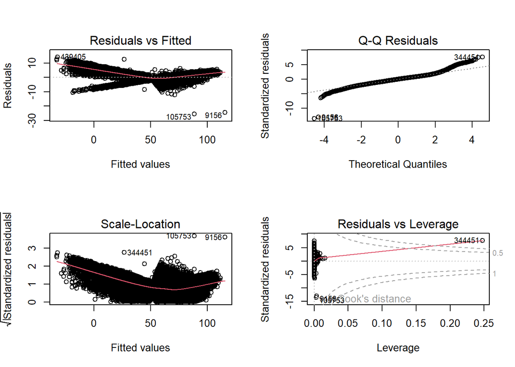

```r
par(mfrow=c(2,2))
plot(multiplelm_withoutdistance)
```